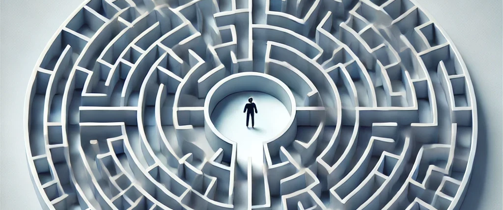

The Challenges of MMM

# The Challenges in Marketing Mix Modeling (MMM)

Marketing Mix Modeling (MMM) has become a critical tool for businesses to understand the effectiveness of their marketing efforts. As privacy concerns grow and the digital landscape shifts, MMM is increasingly replacing more granular attribution methods like Multi-Touch Attribution (MTA). However, while MMM offers a robust way to analyze the impact of marketing channels, it comes with significant challenges. Let’s explore some of the most pressing issues that teams face when embarking on an MMM journey.

### Team and Talent: A Specialized Skill Set

MMM requires more than just general data science capabilities; it demands a specialized set of skills in statistics, programming languages (such as Python, R, SQL), and specific expertise in MMM methodologies. This is not merely about running statistical models; it’s about understanding the nuances of marketing, the pitfalls of biased data, and the intricacies of how media affects consumer behavior.

Unfortunately, this type of talent can be quite niche. It’s not enough to have general data professionals—teams need individuals trained specifically in MMM. These professionals must understand fundamental concepts like saturation, diminishing returns, and carryover effects. They also need to be familiar with potential issues, such as overfitting or multicollinearity. Building or hiring such a team can be a significant challenge, especially since this expertise is in high demand and short supply.

### Data Collection: Historical Data is Key

Once you have the right team in place, the next hurdle is data. MMM requires consistent historical data for at least three years, across a wide variety of variables. This includes everything from sales KPIs to media metrics like spend, clicks, impressions, and TV ratings. But that’s just the start. Operational changes, like website updates, distribution shifts, and promotions, must also be captured.

The data landscape is often messy. Businesses frequently change their infrastructure, switch media agencies, or undergo significant operational changes, all of which can make data collection inconsistent. Missing or unreliable data poses a challenge to building an accurate model. Ensuring that this historical data is both comprehensive and clean requires substantial effort, further adding to the complexity of MMM.

### The Tools: Automation vs. Customization

There are many tools available for MMM, from open-source solutions like Facebook’s Robyn to paid software that offers more automation. Some tools are fully automated, allowing even non-technical marketers to generate insights. Others require more manual scripting in Python or R, offering deeper customization and flexibility.

The challenge lies in choosing between these approaches. Automated tools can provide simplicity and speed but might not offer the flexibility to accommodate every business’s unique needs. On the other hand, custom-built solutions, while offering more control, require a higher level of expertise and often take longer to implement. This trade-off between simplicity and analytical depth is a significant consideration for businesses starting their MMM journey.

### Collinearity: The Data Dilemma

Even with the right team and tools in place, one of the toughest challenges in MMM is dealing with collinearity—when different media channels are highly correlated. For example, TV ads and online display ads might both rise during the same promotional period. When this happens, it becomes difficult for the model to assign the correct uplift to each channel.

Collinearity can lead to inaccurate conclusions about which media drives sales, resulting in poor allocation of future marketing spend. Tackling this issue requires sophisticated modeling techniques, such as using regularization methods or constraints, but these approaches often come with their own trade-offs in terms of complexity and interpretability.

### Conclusion: Navigating the MMM Journey

MMM is a powerful tool for understanding marketing effectiveness, but it comes with its fair share of challenges. From finding the right team with specialized skills to managing the complexities of data collection and choosing between various tools, businesses need to invest considerable time and resources. Moreover, technical challenges like collinearity add an extra layer of difficulty to achieving accurate results.

Despite these hurdles, MMM remains a valuable approach for businesses looking to optimize their marketing spend. With the right combination of talent, data, and tools, organizations can unlock meaningful insights that drive growth and profitability.